# Risk Factor Analysis

## Outcome Variable

**Outcome Variable:** ever_stunted

## Predictor Variables

**Intervention Variable:** enwast

**Adjustment Set:**

- arm
- sex
- W_mage
- meducyrs
- feducyrs
- W_mhtcm
- vagbrth
- single
- brthmon
- W_parity
- delta_W_mage
- delta_meducyrs
- delta_feducyrs
- delta_W_mhtcm
- delta_vagbrth
- delta_single
- delta_brthmon
- delta_W_parity

## Stratifying Variables

The analysis was stratified on these variable(s):

- agecat
- studyid
- country

## Data Summary

| agecat | studyid | country | enwast | ever_stunted | n_cell | n |
| --- | --- | --- | --- | --- | --- | --- |
| 0-6 months | ki0047075b-MAL-ED | BANGLADESH | 0 | 0 | 174 | 241 |
| 0-6 months | ki0047075b-MAL-ED | BANGLADESH | 0 | 1 | 27 | 241 |
| 0-6 months | ki0047075b-MAL-ED | BANGLADESH | 1 | 0 | 36 | 241 |
| 0-6 months | ki0047075b-MAL-ED | BANGLADESH | 1 | 1 | 4 | 241 |
| 0-6 months | ki0047075b-MAL-ED | BRAZIL | 0 | 0 | 163 | 183 |
| 0-6 months | ki0047075b-MAL-ED | BRAZIL | 0 | 1 | 14 | 183 |
| 0-6 months | ki0047075b-MAL-ED | BRAZIL | 1 | 0 | 6 | 183 |
| 0-6 months | ki0047075b-MAL-ED | BRAZIL | 1 | 1 | 0 | 183 |
| 0-6 months | ki0047075b-MAL-ED | INDIA | 0 | 0 | 146 | 203 |
| 0-6 months | ki0047075b-MAL-ED | INDIA | 0 | 1 | 24 | 203 |
| 0-6 months | ki0047075b-MAL-ED | INDIA | 1 | 0 | 27 | 203 |
| 0-6 months | ki0047075b-MAL-ED | INDIA | 1 | 1 | 6 | 203 |
| 0-6 months | ki0047075b-MAL-ED | NEPAL | 0 | 0 | 136 | 169 |
| 0-6 months | ki0047075b-MAL-ED | NEPAL | 0 | 1 | 12 | 169 |
| 0-6 months | ki0047075b-MAL-ED | NEPAL | 1 | 0 | 19 | 169 |
| 0-6 months | ki0047075b-MAL-ED | NEPAL | 1 | 1 | 2 | 169 |
| 0-6 months | ki0047075b-MAL-ED | PERU | 0 | 0 | 248 | 279 |
| 0-6 months | ki0047075b-MAL-ED | PERU | 0 | 1 | 25 | 279 |
| 0-6 months | ki0047075b-MAL-ED | PERU | 1 | 0 | 5 | 279 |
| 0-6 months | ki0047075b-MAL-ED | PERU | 1 | 1 | 1 | 279 |
| 0-6 months | ki0047075b-MAL-ED | SOUTH AFRICA | 0 | 0 | 218 | 260 |
| 0-6 months | ki0047075b-MAL-ED | SOUTH AFRICA | 0 | 1 | 22 | 260 |
| 0-6 months | ki0047075b-MAL-ED | SOUTH AFRICA | 1 | 0 | 16 | 260 |
| 0-6 months | ki0047075b-MAL-ED | SOUTH AFRICA | 1 | 1 | 4 | 260 |
| 0-6 months | ki0047075b-MAL-ED | TANZANIA, UNITED REPUBLIC OF | 0 | 0 | 104 | 118 |
| 0-6 months | ki0047075b-MAL-ED | TANZANIA, UNITED REPUBLIC OF | 0 | 1 | 12 | 118 |
| 0-6 months | ki0047075b-MAL-ED | TANZANIA, UNITED REPUBLIC OF | 1 | 0 | 1 | 118 |
| 0-6 months | ki0047075b-MAL-ED | TANZANIA, UNITED REPUBLIC OF | 1 | 1 | 1 | 118 |
| 0-6 months | ki1000108-CMC-V-BCS-2002 | INDIA | 0 | 0 | 65 | 92 |
| 0-6 months | ki1000108-CMC-V-BCS-2002 | INDIA | 0 | 1 | 9 | 92 |

[output cut: 344 more lines]

The following strata were considered:

- agecat: 0-24 months, studyid: ki0047075b-MAL-ED, country: BANGLADESH
- agecat: 0-24 months, studyid: ki0047075b-MAL-ED, country: BRAZIL
- agecat: 0-24 months, studyid: ki0047075b-MAL-ED, country: INDIA
- agecat: 0-24 months, studyid: ki0047075b-MAL-ED, country: NEPAL
- agecat: 0-24 months, studyid: ki0047075b-MAL-ED, country: PERU
- agecat: 0-24 months, studyid: ki0047075b-MAL-ED, country: SOUTH AFRICA
- agecat: 0-24 months, studyid: ki0047075b-MAL-ED, country: TANZANIA, UNITED REPUBLIC OF
- agecat: 0-24 months, studyid: ki1000108-CMC-V-BCS-2002, country: INDIA
- agecat: 0-24 months, studyid: ki1000108-IRC, country: INDIA
- agecat: 0-24 months, studyid: ki1000109-EE, country: PAKISTAN
- agecat: 0-24 months, studyid: ki1000109-ResPak, country: PAKISTAN
- agecat: 0-24 months, studyid: ki1000304b-SAS-CompFeed, country: INDIA
- agecat: 0-24 months, studyid: ki1000304b-SAS-FoodSuppl, country: INDIA
- agecat: 0-24 months, studyid: ki1017093-NIH-Birth, country: BANGLADESH
- agecat: 0-24 months, studyid: ki1017093c-NIH-Crypto, country: BANGLADESH
- agecat: 0-24 months, studyid: ki1066203-TanzaniaChild2, country: TANZANIA, UNITED REPUBLIC OF
- agecat: 0-24 months, studyid: ki1101329-Keneba, country: GAMBIA
- agecat: 0-24 months, studyid: ki1112895-Guatemala BSC, country: GUATEMALA
- agecat: 0-24 months, studyid: ki1112895-iLiNS-Zinc, country: BURKINA FASO
- agecat: 0-24 months, studyid: ki1113344-GMS-Nepal, country: NEPAL
- agecat: 0-24 months, studyid: ki1114097-CMIN, country: BANGLADESH
- agecat: 0-24 months, studyid: ki1114097-CMIN, country: BRAZIL
- agecat: 0-24 months, studyid: ki1114097-CMIN, country: GUINEA-BISSAU
- agecat: 0-24 months, studyid: ki1114097-CMIN, country: PERU
- agecat: 0-24 months, studyid: ki1114097-CONTENT, country: PERU
- agecat: 0-24 months, studyid: ki1119695-PROBIT, country: BELARUS
- agecat: 0-24 months, studyid: ki1126311-ZVITAMBO, country: ZIMBABWE
- agecat: 0-24 months, studyid: ki1135781-COHORTS, country: GUATEMALA
- agecat: 0-24 months, studyid: ki1135781-COHORTS, country: INDIA
- agecat: 0-24 months, studyid: ki1135781-COHORTS, country: PHILIPPINES
- agecat: 0-24 months, studyid: ki1148112-LCNI-5, country: MALAWI
- agecat: 0-24 months, studyid: kiGH5241-JiVitA-3, country: BANGLADESH
- agecat: 0-24 months, studyid: kiGH5241-JiVitA-4, country: BANGLADESH
- agecat: 0-6 months, studyid: ki0047075b-MAL-ED, country: BANGLADESH
- agecat: 0-6 months, studyid: ki0047075b-MAL-ED, country: BRAZIL
- agecat: 0-6 months, studyid: ki0047075b-MAL-ED, country: INDIA
- agecat: 0-6 months, studyid: ki0047075b-MAL-ED, country: NEPAL
- agecat: 0-6 months, studyid: ki0047075b-MAL-ED, country: PERU
- agecat: 0-6 months, studyid: ki0047075b-MAL-ED, country: SOUTH AFRICA
- agecat: 0-6 months, studyid: ki0047075b-MAL-ED, country: TANZANIA, UNITED REPUBLIC OF
- agecat: 0-6 months, studyid: ki1000108-CMC-V-BCS-2002, country: INDIA
- agecat: 0-6 months, studyid: ki1000108-IRC, country: INDIA
- agecat: 0-6 months, studyid: ki1000109-EE, country: PAKISTAN
- agecat: 0-6 months, studyid: ki1000109-ResPak, country: PAKISTAN
- agecat: 0-6 months, studyid: ki1000304b-SAS-CompFeed, country: INDIA
- agecat: 0-6 months, studyid: ki1000304b-SAS-FoodSuppl, country: INDIA
- agecat: 0-6 months, studyid: ki1017093-NIH-Birth, country: BANGLADESH
- agecat: 0-6 months, studyid: ki1017093c-NIH-Crypto, country: BANGLADESH
- agecat: 0-6 months, studyid: ki1066203-TanzaniaChild2, country: TANZANIA, UNITED REPUBLIC OF
- agecat: 0-6 months, studyid: ki1101329-Keneba, country: GAMBIA
- agecat: 0-6 months, studyid: ki1112895-Guatemala BSC, country: GUATEMALA
- agecat: 0-6 months, studyid: ki1113344-GMS-Nepal, country: NEPAL
- agecat: 0-6 months, studyid: ki1114097-CMIN, country: BANGLADESH
- agecat: 0-6 months, studyid: ki1114097-CMIN, country: BRAZIL
- agecat: 0-6 months, studyid: ki1114097-CMIN, country: GUINEA-BISSAU
- agecat: 0-6 months, studyid: ki1114097-CMIN, country: PERU
- agecat: 0-6 months, studyid: ki1114097-CONTENT, country: PERU
- agecat: 0-6 months, studyid: ki1119695-PROBIT, country: BELARUS
- agecat: 0-6 months, studyid: ki1126311-ZVITAMBO, country: ZIMBABWE
- agecat: 0-6 months, studyid: ki1135781-COHORTS, country: GUATEMALA
- agecat: 0-6 months, studyid: ki1135781-COHORTS, country: INDIA
- agecat: 0-6 months, studyid: ki1135781-COHORTS, country: PHILIPPINES
- agecat: 0-6 months, studyid: ki1148112-LCNI-5, country: MALAWI
- agecat: 0-6 months, studyid: kiGH5241-JiVitA-3, country: BANGLADESH
- agecat: 0-6 months, studyid: kiGH5241-JiVitA-4, country: BANGLADESH
- agecat: 6-24 months, studyid: ki0047075b-MAL-ED, country: BANGLADESH
- agecat: 6-24 months, studyid: ki0047075b-MAL-ED, country: BRAZIL
- agecat: 6-24 months, studyid: ki0047075b-MAL-ED, country: INDIA
- agecat: 6-24 months, studyid: ki0047075b-MAL-ED, country: NEPAL
- agecat: 6-24 months, studyid: ki0047075b-MAL-ED, country: PERU
- agecat: 6-24 months, studyid: ki0047075b-MAL-ED, country: SOUTH AFRICA
- agecat: 6-24 months, studyid: ki0047075b-MAL-ED, country: TANZANIA, UNITED REPUBLIC OF
- agecat: 6-24 months, studyid: ki1000108-CMC-V-BCS-2002, country: INDIA
- agecat: 6-24 months, studyid: ki1000108-IRC, country: INDIA
- agecat: 6-24 months, studyid: ki1000109-EE, country: PAKISTAN
- agecat: 6-24 months, studyid: ki1000109-ResPak, country: PAKISTAN
- agecat: 6-24 months, studyid: ki1000304b-SAS-CompFeed, country: INDIA
- agecat: 6-24 months, studyid: ki1000304b-SAS-FoodSuppl, country: INDIA
- agecat: 6-24 months, studyid: ki1017093-NIH-Birth, country: BANGLADESH
- agecat: 6-24 months, studyid: ki1017093c-NIH-Crypto, country: BANGLADESH
- agecat: 6-24 months, studyid: ki1066203-TanzaniaChild2, country: TANZANIA, UNITED REPUBLIC OF
- agecat: 6-24 months, studyid: ki1101329-Keneba, country: GAMBIA
- agecat: 6-24 months, studyid: ki1112895-Guatemala BSC, country: GUATEMALA
- agecat: 6-24 months, studyid: ki1112895-iLiNS-Zinc, country: BURKINA FASO
- agecat: 6-24 months, studyid: ki1113344-GMS-Nepal, country: NEPAL
- agecat: 6-24 months, studyid: ki1114097-CMIN, country: BRAZIL
- agecat: 6-24 months, studyid: ki1114097-CMIN, country: GUINEA-BISSAU
- agecat: 6-24 months, studyid: ki1114097-CMIN, country: PERU
- agecat: 6-24 months, studyid: ki1114097-CONTENT, country: PERU
- agecat: 6-24 months, studyid: ki1119695-PROBIT, country: BELARUS
- agecat: 6-24 months, studyid: ki1126311-ZVITAMBO, country: ZIMBABWE
- agecat: 6-24 months, studyid: ki1135781-COHORTS, country: GUATEMALA
- agecat: 6-24 months, studyid: ki1135781-COHORTS, country: INDIA
- agecat: 6-24 months, studyid: ki1135781-COHORTS, country: PHILIPPINES
- agecat: 6-24 months, studyid: ki1148112-LCNI-5, country: MALAWI
- agecat: 6-24 months, studyid: kiGH5241-JiVitA-3, country: BANGLADESH
- agecat: 6-24 months, studyid: kiGH5241-JiVitA-4, country: BANGLADESH

### Dropped Strata

Some strata were dropped due to rare outcomes:

- agecat: 0-6 months, studyid: ki0047075b-MAL-ED, country: BANGLADESH
- agecat: 0-6 months, studyid: ki0047075b-MAL-ED, country: BRAZIL
- agecat: 0-6 months, studyid: ki0047075b-MAL-ED, country: NEPAL
- agecat: 0-6 months, studyid: ki0047075b-MAL-ED, country: PERU
- agecat: 0-6 months, studyid: ki0047075b-MAL-ED, country: SOUTH AFRICA
- agecat: 0-6 months, studyid: ki0047075b-MAL-ED, country: TANZANIA, UNITED REPUBLIC OF
- agecat: 0-6 months, studyid: ki1000108-CMC-V-BCS-2002, country: INDIA
- agecat: 0-6 months, studyid: ki1000109-EE, country: PAKISTAN
- agecat: 0-6 months, studyid: ki1000109-ResPak, country: PAKISTAN
- agecat: 0-6 months, studyid: ki1017093c-NIH-Crypto, country: BANGLADESH
- agecat: 0-6 months, studyid: ki1066203-TanzaniaChild2, country: TANZANIA, UNITED REPUBLIC OF
- agecat: 0-6 months, studyid: ki1112895-Guatemala BSC, country: GUATEMALA
- agecat: 0-6 months, studyid: ki1113344-GMS-Nepal, country: NEPAL
- agecat: 0-6 months, studyid: ki1114097-CMIN, country: BANGLADESH
- agecat: 0-6 months, studyid: ki1114097-CMIN, country: BRAZIL
- agecat: 0-6 months, studyid: ki1114097-CMIN, country: GUINEA-BISSAU
- agecat: 0-6 months, studyid: ki1114097-CMIN, country: PERU
- agecat: 0-6 months, studyid: ki1119695-PROBIT, country: BELARUS
- agecat: 0-6 months, studyid: ki1135781-COHORTS, country: GUATEMALA
- agecat: 0-6 months, studyid: ki1148112-LCNI-5, country: MALAWI
- agecat: 6-24 months, studyid: ki0047075b-MAL-ED, country: BRAZIL
- agecat: 6-24 months, studyid: ki0047075b-MAL-ED, country: INDIA
- agecat: 6-24 months, studyid: ki0047075b-MAL-ED, country: NEPAL
- agecat: 6-24 months, studyid: ki0047075b-MAL-ED, country: PERU
- agecat: 6-24 months, studyid: ki0047075b-MAL-ED, country: SOUTH AFRICA
- agecat: 6-24 months, studyid: ki0047075b-MAL-ED, country: TANZANIA, UNITED REPUBLIC OF
- agecat: 6-24 months, studyid: ki1000108-CMC-V-BCS-2002, country: INDIA
- agecat: 6-24 months, studyid: ki1000109-EE, country: PAKISTAN
- agecat: 6-24 months, studyid: ki1000109-ResPak, country: PAKISTAN
- agecat: 6-24 months, studyid: ki1017093c-NIH-Crypto, country: BANGLADESH
- agecat: 6-24 months, studyid: ki1066203-TanzaniaChild2, country: TANZANIA, UNITED REPUBLIC OF
- agecat: 6-24 months, studyid: ki1112895-Guatemala BSC, country: GUATEMALA
- agecat: 6-24 months, studyid: ki1113344-GMS-Nepal, country: NEPAL
- agecat: 6-24 months, studyid: ki1114097-CMIN, country: BRAZIL
- agecat: 6-24 months, studyid: ki1114097-CMIN, country: GUINEA-BISSAU
- agecat: 6-24 months, studyid: ki1114097-CMIN, country: PERU
- agecat: 6-24 months, studyid: ki1114097-CONTENT, country: PERU
- agecat: 6-24 months, studyid: ki1148112-LCNI-5, country: MALAWI
- agecat: 0-24 months, studyid: ki0047075b-MAL-ED, country: BRAZIL
- agecat: 0-24 months, studyid: ki0047075b-MAL-ED, country: PERU
- agecat: 0-24 months, studyid: ki0047075b-MAL-ED, country: TANZANIA, UNITED REPUBLIC OF
- agecat: 0-24 months, studyid: ki1000108-CMC-V-BCS-2002, country: INDIA
- agecat: 0-24 months, studyid: ki1000109-EE, country: PAKISTAN
- agecat: 0-24 months, studyid: ki1000109-ResPak, country: PAKISTAN
- agecat: 0-24 months, studyid: ki1017093c-NIH-Crypto, country: BANGLADESH
- agecat: 0-24 months, studyid: ki1112895-Guatemala BSC, country: GUATEMALA
- agecat: 0-24 months, studyid: ki1113344-GMS-Nepal, country: NEPAL
- agecat: 0-24 months, studyid: ki1114097-CMIN, country: BANGLADESH
- agecat: 0-24 months, studyid: ki1114097-CMIN, country: BRAZIL
- agecat: 0-24 months, studyid: ki1114097-CMIN, country: PERU

## Methods Detail

We’re interested in the causal parameters $E[Y_a]$ for all values of $a \in \mathcal{A}$. These parameters represent the mean outcome if, possibly contrary to fact, we intervened to set all units to have $A=a$. Under the randomization and positivity assumptions, these are identified by the statistical parameters $\psi_a=E_W[E_{Y|A,W}(Y|A=a,W)]$. In addition, we’re interested in the mean of $Y$, $E[Y]$ under no intervention (the observed mean). We will estimate these parameters by using SuperLearner to fit the relevant likelihood factors – $E_{Y|A,W}(Y|A=a,W)$ and $p(A=a|W)$, and then updating our likelihood fit using a joint TMLE.

For unadjusted analyses ($W=\{\}$), initial likelihoods were estimated using Lrnr_glm to estimate the simple $E(Y|A)$ and Lrnr_mean to estimate $p(A)$. For adjusted analyses, a small library containing Lrnr_glmnet, Lrnr_xgboost, and Lrnr_mean was used.

Having estimated these parameters, we will then use the delta method to estimate relative risks and attributable risks relative to a prespecified baseline level of $A$.

[output not shown]

[output not shown]

[output not shown]

# Results Detail

## Results Plots

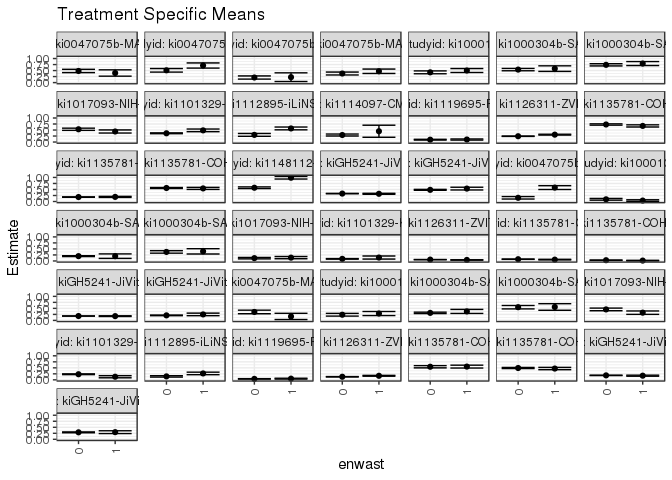

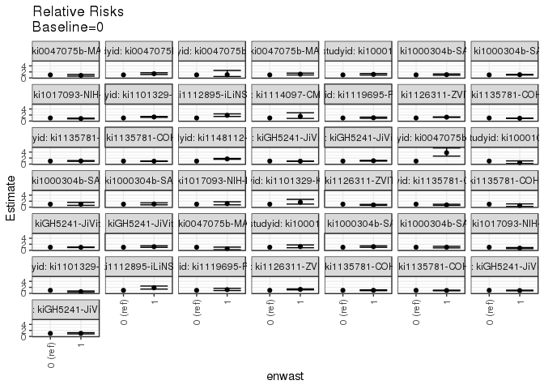

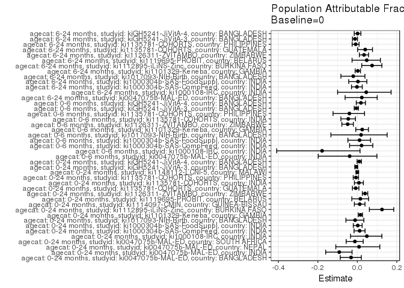

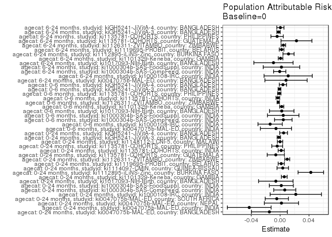

## Results Table

### Parameter: TSM

| agecat | studyid | country | intervention_level | baseline_level | estimate | ci_lower | ci_upper |
| --- | --- | --- | --- | --- | --- | --- | --- |
| 0-24 months | ki0047075b-MAL-ED | BANGLADESH | 0 | NA | 0.4837523 | 0.4161571 | 0.5513475 |
| 0-24 months | ki0047075b-MAL-ED | BANGLADESH | 1 | NA | 0.3989907 | 0.2669953 | 0.5309862 |
| 0-24 months | ki0047075b-MAL-ED | INDIA | 0 | NA | 0.5107556 | 0.4369343 | 0.5845768 |
| 0-24 months | ki0047075b-MAL-ED | INDIA | 1 | NA | 0.7103296 | 0.6030795 | 0.8175797 |
| 0-24 months | ki0047075b-MAL-ED | NEPAL | 0 | NA | 0.2111612 | 0.1455016 | 0.2768208 |
| 0-24 months | ki0047075b-MAL-ED | NEPAL | 1 | NA | 0.2255450 | 0.0459561 | 0.4051338 |
| 0-24 months | ki0047075b-MAL-ED | SOUTH AFRICA | 0 | NA | 0.3777203 | 0.3172326 | 0.4382080 |
| 0-24 months | ki0047075b-MAL-ED | SOUTH AFRICA | 1 | NA | 0.4710500 | 0.3792205 | 0.5628796 |
| 0-24 months | ki1000108-IRC | INDIA | 0 | NA | 0.4267733 | 0.3667777 | 0.4867689 |
| 0-24 months | ki1000108-IRC | INDIA | 1 | NA | 0.5023765 | 0.4200300 | 0.5847229 |
| 0-24 months | ki1000304b-SAS-CompFeed | INDIA | 0 | NA | 0.5407618 | 0.4924780 | 0.5890457 |
| 0-24 months | ki1000304b-SAS-CompFeed | INDIA | 1 | NA | 0.5809749 | 0.4652364 | 0.6967134 |
| 0-24 months | ki1000304b-SAS-FoodSuppl | INDIA | 0 | NA | 0.7384441 | 0.6923941 | 0.7844941 |
| 0-24 months | ki1000304b-SAS-FoodSuppl | INDIA | 1 | NA | 0.7921801 | 0.7093992 | 0.8749611 |
| 0-24 months | ki1017093-NIH-Birth | BANGLADESH | 0 | NA | 0.5311124 | 0.4850230 | 0.5772017 |
| 0-24 months | ki1017093-NIH-Birth | BANGLADESH | 1 | NA | 0.4388592 | 0.3744358 | 0.5032825 |
| 0-24 months | ki1101329-Keneba | GAMBIA | 0 | NA | 0.3642544 | 0.3463238 | 0.3821850 |
| 0-24 months | ki1101329-Keneba | GAMBIA | 1 | NA | 0.4857687 | 0.4312519 | 0.5402855 |
| 0-24 months | ki1112895-iLiNS-Zinc | BURKINA FASO | 0 | NA | 0.2977632 | 0.2383080 | 0.3572185 |
| 0-24 months | ki1112895-iLiNS-Zinc | BURKINA FASO | 1 | NA | 0.5655826 | 0.5078858 | 0.6232794 |
| 0-24 months | ki1114097-CMIN | GUINEA-BISSAU | 0 | NA | 0.2928272 | 0.2514077 | 0.3342468 |
| 0-24 months | ki1114097-CMIN | GUINEA-BISSAU | 1 | NA | 0.4494290 | 0.1987113 | 0.7001467 |
| 0-24 months | ki1119695-PROBIT | BELARUS | 0 | NA | 0.0978749 | 0.0816367 | 0.1141132 |
| 0-24 months | ki1119695-PROBIT | BELARUS | 1 | NA | 0.1050405 | 0.0819737 | 0.1281072 |
| 0-24 months | ki1126311-ZVITAMBO | ZIMBABWE | 0 | NA | 0.2419701 | 0.2339846 | 0.2499556 |
| 0-24 months | ki1126311-ZVITAMBO | ZIMBABWE | 1 | NA | 0.3073657 | 0.2898050 | 0.3249264 |
| 0-24 months | ki1135781-COHORTS | GUATEMALA | 0 | NA | 0.7300682 | 0.7021499 | 0.7579865 |
| 0-24 months | ki1135781-COHORTS | GUATEMALA | 1 | NA | 0.6705577 | 0.6260185 | 0.7150969 |
| 0-24 months | ki1135781-COHORTS | INDIA | 0 | NA | 0.1847691 | 0.1746942 | 0.1948441 |
| 0-24 months | ki1135781-COHORTS | INDIA | 1 | NA | 0.1913879 | 0.1703177 | 0.2124580 |

[output cut: 56 more lines]

### Parameter: E(Y)

| agecat | studyid | country | intervention_level | baseline_level | estimate | ci_lower | ci_upper |
| --- | --- | --- | --- | --- | --- | --- | --- |
| 0-24 months | ki0047075b-MAL-ED | BANGLADESH | NA | NA | 0.4688797 | 0.4057447 | 0.5320146 |
| 0-24 months | ki0047075b-MAL-ED | INDIA | NA | NA | 0.4679803 | 0.3991705 | 0.5367901 |
| 0-24 months | ki0047075b-MAL-ED | NEPAL | NA | NA | 0.2130178 | 0.1511045 | 0.2749310 |
| 0-24 months | ki0047075b-MAL-ED | SOUTH AFRICA | NA | NA | 0.3730769 | 0.3141784 | 0.4319755 |
| 0-24 months | ki1000108-IRC | INDIA | NA | NA | 0.4484536 | 0.3989038 | 0.4980035 |
| 0-24 months | ki1000304b-SAS-CompFeed | INDIA | NA | NA | 0.5471836 | 0.5012688 | 0.5930984 |
| 0-24 months | ki1000304b-SAS-FoodSuppl | INDIA | NA | NA | 0.7400990 | 0.6972792 | 0.7829188 |
| 0-24 months | ki1017093-NIH-Birth | BANGLADESH | NA | NA | 0.5251678 | 0.4850434 | 0.5652922 |
| 0-24 months | ki1101329-Keneba | GAMBIA | NA | NA | 0.3700000 | 0.3524250 | 0.3875750 |
| 0-24 months | ki1112895-iLiNS-Zinc | BURKINA FASO | NA | NA | 0.3402910 | 0.2902222 | 0.3903597 |
| 0-24 months | ki1114097-CMIN | GUINEA-BISSAU | NA | NA | 0.2964509 | 0.2555100 | 0.3373919 |
| 0-24 months | ki1119695-PROBIT | BELARUS | NA | NA | 0.0994093 | 0.0831494 | 0.1156692 |
| 0-24 months | ki1126311-ZVITAMBO | ZIMBABWE | NA | NA | 0.2518293 | 0.2444016 | 0.2592569 |
| 0-24 months | ki1135781-COHORTS | GUATEMALA | NA | NA | 0.7240461 | 0.6979377 | 0.7501545 |
| 0-24 months | ki1135781-COHORTS | INDIA | NA | NA | 0.1862902 | 0.1770836 | 0.1954968 |
| 0-24 months | ki1135781-COHORTS | PHILIPPINES | NA | NA | 0.5571968 | 0.5391496 | 0.5752441 |
| 0-24 months | ki1148112-LCNI-5 | MALAWI | NA | NA | 0.5719468 | 0.5382037 | 0.6056899 |
| 0-24 months | kiGH5241-JiVitA-3 | BANGLADESH | NA | NA | 0.3276966 | 0.3200516 | 0.3353416 |
| 0-24 months | kiGH5241-JiVitA-4 | BANGLADESH | NA | NA | 0.4898224 | 0.4725918 | 0.5070530 |
| 0-6 months | ki0047075b-MAL-ED | INDIA | NA | NA | 0.1477833 | 0.0988437 | 0.1967228 |
| 0-6 months | ki1000108-IRC | INDIA | NA | NA | 0.0773196 | 0.0507085 | 0.1039307 |
| 0-6 months | ki1000304b-SAS-CompFeed | INDIA | NA | NA | 0.2048281 | 0.1851668 | 0.2244894 |
| 0-6 months | ki1000304b-SAS-FoodSuppl | INDIA | NA | NA | 0.3796526 | 0.3322125 | 0.4270927 |
| 0-6 months | ki1017093-NIH-Birth | BANGLADESH | NA | NA | 0.1191275 | 0.0930988 | 0.1451562 |
| 0-6 months | ki1101329-Keneba | GAMBIA | NA | NA | 0.0893878 | 0.0780882 | 0.1006873 |
| 0-6 months | ki1126311-ZVITAMBO | ZIMBABWE | NA | NA | 0.0533577 | 0.0495118 | 0.0572037 |
| 0-6 months | ki1135781-COHORTS | INDIA | NA | NA | 0.0693274 | 0.0632740 | 0.0753808 |
| 0-6 months | ki1135781-COHORTS | PHILIPPINES | NA | NA | 0.0295431 | 0.0233911 | 0.0356951 |
| 0-6 months | kiGH5241-JiVitA-3 | BANGLADESH | NA | NA | 0.1805041 | 0.1749565 | 0.1860517 |
| 0-6 months | kiGH5241-JiVitA-4 | BANGLADESH | NA | NA | 0.2136196 | 0.2001838 | 0.2270554 |
| 6-24 months | ki0047075b-MAL-ED | BANGLADESH | NA | NA | 0.3602151 | 0.2910383 | 0.4293918 |
| 6-24 months | ki1000108-IRC | INDIA | NA | NA | 0.2469136 | 0.1998872 | 0.2939400 |
| 6-24 months | ki1000304b-SAS-CompFeed | INDIA | NA | NA | 0.3124324 | 0.2808301 | 0.3440347 |
| 6-24 months | ki1000304b-SAS-FoodSuppl | INDIA | NA | NA | 0.5504587 | 0.4842728 | 0.6166446 |
| 6-24 months | ki1017093-NIH-Birth | BANGLADESH | NA | NA | 0.4476886 | 0.3995563 | 0.4958208 |
| 6-24 months | ki1101329-Keneba | GAMBIA | NA | NA | 0.2342761 | 0.2172169 | 0.2513352 |
| 6-24 months | ki1112895-iLiNS-Zinc | BURKINA FASO | NA | NA | 0.1555985 | 0.1280985 | 0.1830984 |
| 6-24 months | ki1119695-PROBIT | BELARUS | NA | NA | 0.0428289 | 0.0325550 | 0.0531028 |
| 6-24 months | ki1126311-ZVITAMBO | ZIMBABWE | NA | NA | 0.1335298 | 0.1264315 | 0.1406281 |
| 6-24 months | ki1135781-COHORTS | GUATEMALA | NA | NA | 0.5675676 | 0.5248634 | 0.6102718 |
| 6-24 months | ki1135781-COHORTS | PHILIPPINES | NA | NA | 0.4884793 | 0.4674428 | 0.5095157 |
| 6-24 months | kiGH5241-JiVitA-3 | BANGLADESH | NA | NA | 0.1841492 | 0.1759877 | 0.1923107 |
| 6-24 months | kiGH5241-JiVitA-4 | BANGLADESH | NA | NA | 0.2909471 | 0.2737460 | 0.3081483 |

### Parameter: RR

| agecat | studyid | country | intervention_level | baseline_level | estimate | ci_lower | ci_upper |
| --- | --- | --- | --- | --- | --- | --- | --- |
| 0-24 months | ki0047075b-MAL-ED | BANGLADESH | 0 | 0 | 1.0000000 | 1.0000000 | 1.0000000 |
| 0-24 months | ki0047075b-MAL-ED | BANGLADESH | 1 | 0 | 0.8247830 | 0.5830006 | 1.1668376 |
| 0-24 months | ki0047075b-MAL-ED | INDIA | 0 | 0 | 1.0000000 | 1.0000000 | 1.0000000 |
| 0-24 months | ki0047075b-MAL-ED | INDIA | 1 | 0 | 1.3907428 | 1.1329785 | 1.7071511 |
| 0-24 months | ki0047075b-MAL-ED | NEPAL | 0 | 0 | 1.0000000 | 1.0000000 | 1.0000000 |
| 0-24 months | ki0047075b-MAL-ED | NEPAL | 1 | 0 | 1.0681173 | 0.4557292 | 2.5034044 |
| 0-24 months | ki0047075b-MAL-ED | SOUTH AFRICA | 0 | 0 | 1.0000000 | 1.0000000 | 1.0000000 |
| 0-24 months | ki0047075b-MAL-ED | SOUTH AFRICA | 1 | 0 | 1.2470869 | 0.9794934 | 1.5877858 |
| 0-24 months | ki1000108-IRC | INDIA | 0 | 0 | 1.0000000 | 1.0000000 | 1.0000000 |
| 0-24 months | ki1000108-IRC | INDIA | 1 | 0 | 1.1771507 | 0.9488666 | 1.4603568 |
| 0-24 months | ki1000304b-SAS-CompFeed | INDIA | 0 | 0 | 1.0000000 | 1.0000000 | 1.0000000 |
| 0-24 months | ki1000304b-SAS-CompFeed | INDIA | 1 | 0 | 1.0743637 | 0.8708776 | 1.3253957 |
| 0-24 months | ki1000304b-SAS-FoodSuppl | INDIA | 0 | 0 | 1.0000000 | 1.0000000 | 1.0000000 |
| 0-24 months | ki1000304b-SAS-FoodSuppl | INDIA | 1 | 0 | 1.0727692 | 0.9565917 | 1.2030565 |
| 0-24 months | ki1017093-NIH-Birth | BANGLADESH | 0 | 0 | 1.0000000 | 1.0000000 | 1.0000000 |
| 0-24 months | ki1017093-NIH-Birth | BANGLADESH | 1 | 0 | 0.8263019 | 0.7000058 | 0.9753844 |
| 0-24 months | ki1101329-Keneba | GAMBIA | 0 | 0 | 1.0000000 | 1.0000000 | 1.0000000 |
| 0-24 months | ki1101329-Keneba | GAMBIA | 1 | 0 | 1.3335972 | 1.1816420 | 1.5050934 |
| 0-24 months | ki1112895-iLiNS-Zinc | BURKINA FASO | 0 | 0 | 1.0000000 | 1.0000000 | 1.0000000 |
| 0-24 months | ki1112895-iLiNS-Zinc | BURKINA FASO | 1 | 0 | 1.8994372 | 1.5168116 | 2.3785827 |
| 0-24 months | ki1114097-CMIN | GUINEA-BISSAU | 0 | 0 | 1.0000000 | 1.0000000 | 1.0000000 |
| 0-24 months | ki1114097-CMIN | GUINEA-BISSAU | 1 | 0 | 1.5347924 | 0.8629957 | 2.7295475 |
| 0-24 months | ki1119695-PROBIT | BELARUS | 0 | 0 | 1.0000000 | 1.0000000 | 1.0000000 |
| 0-24 months | ki1119695-PROBIT | BELARUS | 1 | 0 | 1.0732110 | 0.8911987 | 1.2923963 |
| 0-24 months | ki1126311-ZVITAMBO | ZIMBABWE | 0 | 0 | 1.0000000 | 1.0000000 | 1.0000000 |
| 0-24 months | ki1126311-ZVITAMBO | ZIMBABWE | 1 | 0 | 1.2702632 | 1.1897480 | 1.3562271 |
| 0-24 months | ki1135781-COHORTS | GUATEMALA | 0 | 0 | 1.0000000 | 1.0000000 | 1.0000000 |
| 0-24 months | ki1135781-COHORTS | GUATEMALA | 1 | 0 | 0.9184863 | 0.8522002 | 0.9899284 |
| 0-24 months | ki1135781-COHORTS | INDIA | 0 | 0 | 1.0000000 | 1.0000000 | 1.0000000 |
| 0-24 months | ki1135781-COHORTS | INDIA | 1 | 0 | 1.0358217 | 0.9167637 | 1.1703414 |

[output cut: 56 more lines]

### Parameter: PAR

| agecat | studyid | country | intervention_level | baseline_level | estimate | ci_lower | ci_upper |
| --- | --- | --- | --- | --- | --- | --- | --- |
| 0-24 months | ki0047075b-MAL-ED | BANGLADESH | 0 | NA | -0.0148727 | -0.0397438 | 0.0099985 |
| 0-24 months | ki0047075b-MAL-ED | INDIA | 0 | NA | -0.0427753 | -0.0730359 | -0.0125146 |
| 0-24 months | ki0047075b-MAL-ED | NEPAL | 0 | NA | 0.0018565 | -0.0218498 | 0.0255628 |
| 0-24 months | ki0047075b-MAL-ED | SOUTH AFRICA | 0 | NA | -0.0046434 | -0.0207287 | 0.0114419 |
| 0-24 months | ki1000108-IRC | INDIA | 0 | NA | 0.0216803 | -0.0138750 | 0.0572357 |
| 0-24 months | ki1000304b-SAS-CompFeed | INDIA | 0 | NA | 0.0064218 | -0.0088461 | 0.0216896 |
| 0-24 months | ki1000304b-SAS-FoodSuppl | INDIA | 0 | NA | 0.0016549 | -0.0149309 | 0.0182407 |
| 0-24 months | ki1017093-NIH-Birth | BANGLADESH | 0 | NA | -0.0059446 | -0.0298199 | 0.0179307 |
| 0-24 months | ki1101329-Keneba | GAMBIA | 0 | NA | 0.0057456 | 0.0017555 | 0.0097356 |
| 0-24 months | ki1112895-iLiNS-Zinc | BURKINA FASO | 0 | NA | 0.0425277 | 0.0248644 | 0.0601910 |
| 0-24 months | ki1114097-CMIN | GUINEA-BISSAU | 0 | NA | 0.0036237 | -0.0043379 | 0.0115853 |
| 0-24 months | ki1119695-PROBIT | BELARUS | 0 | NA | 0.0015344 | -0.0027075 | 0.0057762 |
| 0-24 months | ki1126311-ZVITAMBO | ZIMBABWE | 0 | NA | 0.0098592 | 0.0064100 | 0.0133083 |
| 0-24 months | ki1135781-COHORTS | GUATEMALA | 0 | NA | -0.0060221 | -0.0179243 | 0.0058801 |
| 0-24 months | ki1135781-COHORTS | INDIA | 0 | NA | 0.0015211 | -0.0027107 | 0.0057529 |
| 0-24 months | ki1135781-COHORTS | PHILIPPINES | 0 | NA | -0.0040408 | -0.0115408 | 0.0034593 |
| 0-24 months | ki1148112-LCNI-5 | MALAWI | 0 | NA | -0.0000790 | -0.0038019 | 0.0036439 |
| 0-24 months | kiGH5241-JiVitA-3 | BANGLADESH | 0 | NA | -0.0018024 | -0.0041400 | 0.0005353 |
| 0-24 months | kiGH5241-JiVitA-4 | BANGLADESH | 0 | NA | 0.0048147 | -0.0006086 | 0.0102381 |
| 0-6 months | ki0047075b-MAL-ED | INDIA | 0 | NA | -0.0057367 | -0.0273181 | 0.0158448 |
| 0-6 months | ki1000108-IRC | INDIA | 0 | NA | -0.0138071 | -0.0306387 | 0.0030244 |
| 0-6 months | ki1000304b-SAS-CompFeed | INDIA | 0 | NA | 0.0043939 | -0.0078099 | 0.0165976 |
| 0-6 months | ki1000304b-SAS-FoodSuppl | INDIA | 0 | NA | 0.0042877 | -0.0175176 | 0.0260929 |
| 0-6 months | ki1017093-NIH-Birth | BANGLADESH | 0 | NA | 0.0022505 | -0.0146946 | 0.0191957 |
| 0-6 months | ki1101329-Keneba | GAMBIA | 0 | NA | 0.0022105 | -0.0006673 | 0.0050884 |
| 0-6 months | ki1126311-ZVITAMBO | ZIMBABWE | 0 | NA | -0.0026093 | -0.0041683 | -0.0010502 |
| 0-6 months | ki1135781-COHORTS | INDIA | 0 | NA | -0.0031735 | -0.0057441 | -0.0006029 |
| 0-6 months | ki1135781-COHORTS | PHILIPPINES | 0 | NA | -0.0011872 | -0.0035515 | 0.0011771 |
| 0-6 months | kiGH5241-JiVitA-3 | BANGLADESH | 0 | NA | -0.0008816 | -0.0028019 | 0.0010387 |
| 0-6 months | kiGH5241-JiVitA-4 | BANGLADESH | 0 | NA | 0.0038892 | -0.0011190 | 0.0088974 |
| 6-24 months | ki0047075b-MAL-ED | BANGLADESH | 0 | NA | 0.0081790 | -0.0210633 | 0.0374213 |
| 6-24 months | ki1000108-IRC | INDIA | 0 | NA | 0.0111394 | -0.0222530 | 0.0445318 |
| 6-24 months | ki1000304b-SAS-CompFeed | INDIA | 0 | NA | -0.0005878 | -0.0090866 | 0.0079111 |
| 6-24 months | ki1000304b-SAS-FoodSuppl | INDIA | 0 | NA | 0.0018558 | -0.0234285 | 0.0271401 |
| 6-24 months | ki1017093-NIH-Birth | BANGLADESH | 0 | NA | -0.0092015 | -0.0363845 | 0.0179816 |
| 6-24 months | ki1101329-Keneba | GAMBIA | 0 | NA | 0.0006232 | -0.0025427 | 0.0037890 |
| 6-24 months | ki1112895-iLiNS-Zinc | BURKINA FASO | 0 | NA | 0.0116329 | 0.0039006 | 0.0193652 |
| 6-24 months | ki1119695-PROBIT | BELARUS | 0 | NA | 0.0020459 | -0.0011698 | 0.0052616 |
| 6-24 months | ki1126311-ZVITAMBO | ZIMBABWE | 0 | NA | 0.0045322 | 0.0014081 | 0.0076563 |
| 6-24 months | ki1135781-COHORTS | GUATEMALA | 0 | NA | 0.0226479 | 0.0012130 | 0.0440828 |
| 6-24 months | ki1135781-COHORTS | PHILIPPINES | 0 | NA | -0.0041600 | -0.0127312 | 0.0044112 |
| 6-24 months | kiGH5241-JiVitA-3 | BANGLADESH | 0 | NA | -0.0021848 | -0.0045267 | 0.0001570 |
| 6-24 months | kiGH5241-JiVitA-4 | BANGLADESH | 0 | NA | 0.0003765 | -0.0045514 | 0.0053043 |

### Parameter: PAF

| agecat | studyid | country | intervention_level | baseline_level | estimate | ci_lower | ci_upper |
| --- | --- | --- | --- | --- | --- | --- | --- |
| 0-24 months | ki0047075b-MAL-ED | BANGLADESH | 0 | NA | -0.0317196 | -0.0863819 | 0.0201924 |
| 0-24 months | ki0047075b-MAL-ED | INDIA | 0 | NA | -0.0914040 | -0.1601588 | -0.0267238 |
| 0-24 months | ki0047075b-MAL-ED | NEPAL | 0 | NA | 0.0087153 | -0.1090112 | 0.1139447 |
| 0-24 months | ki0047075b-MAL-ED | SOUTH AFRICA | 0 | NA | -0.0124461 | -0.0566138 | 0.0298753 |
| 0-24 months | ki1000108-IRC | INDIA | 0 | NA | 0.0483447 | -0.0343340 | 0.1244145 |
| 0-24 months | ki1000304b-SAS-CompFeed | INDIA | 0 | NA | 0.0117360 | -0.0165748 | 0.0392585 |
| 0-24 months | ki1000304b-SAS-FoodSuppl | INDIA | 0 | NA | 0.0022361 | -0.0204292 | 0.0243979 |
| 0-24 months | ki1017093-NIH-Birth | BANGLADESH | 0 | NA | -0.0113194 | -0.0578539 | 0.0331680 |
| 0-24 months | ki1101329-Keneba | GAMBIA | 0 | NA | 0.0155286 | 0.0046774 | 0.0262615 |
| 0-24 months | ki1112895-iLiNS-Zinc | BURKINA FASO | 0 | NA | 0.1249746 | 0.0610618 | 0.1845368 |
| 0-24 months | ki1114097-CMIN | GUINEA-BISSAU | 0 | NA | 0.0122236 | -0.0149918 | 0.0387094 |
| 0-24 months | ki1119695-PROBIT | BELARUS | 0 | NA | 0.0154347 | -0.0278935 | 0.0569366 |
| 0-24 months | ki1126311-ZVITAMBO | ZIMBABWE | 0 | NA | 0.0391502 | 0.0253816 | 0.0527242 |
| 0-24 months | ki1135781-COHORTS | GUATEMALA | 0 | NA | -0.0083173 | -0.0249147 | 0.0080114 |
| 0-24 months | ki1135781-COHORTS | INDIA | 0 | NA | 0.0081651 | -0.0148108 | 0.0306208 |
| 0-24 months | ki1135781-COHORTS | PHILIPPINES | 0 | NA | -0.0072520 | -0.0208066 | 0.0061226 |
| 0-24 months | ki1148112-LCNI-5 | MALAWI | 0 | NA | -0.0001382 | -0.0066685 | 0.0063498 |
| 0-24 months | kiGH5241-JiVitA-3 | BANGLADESH | 0 | NA | -0.0055001 | -0.0126674 | 0.0016165 |
| 0-24 months | kiGH5241-JiVitA-4 | BANGLADESH | 0 | NA | 0.0098296 | -0.0013084 | 0.0208437 |
| 0-6 months | ki0047075b-MAL-ED | INDIA | 0 | NA | -0.0388181 | -0.1981347 | 0.0993141 |
| 0-6 months | ki1000108-IRC | INDIA | 0 | NA | -0.1785720 | -0.4083600 | 0.0137238 |
| 0-6 months | ki1000304b-SAS-CompFeed | INDIA | 0 | NA | 0.0214514 | -0.0391435 | 0.0785129 |
| 0-6 months | ki1000304b-SAS-FoodSuppl | INDIA | 0 | NA | 0.0112936 | -0.0478403 | 0.0670904 |
| 0-6 months | ki1017093-NIH-Birth | BANGLADESH | 0 | NA | 0.0188919 | -0.1338973 | 0.1510933 |
| 0-6 months | ki1101329-Keneba | GAMBIA | 0 | NA | 0.0247299 | -0.0078327 | 0.0562403 |
| 0-6 months | ki1126311-ZVITAMBO | ZIMBABWE | 0 | NA | -0.0489017 | -0.0783878 | -0.0202218 |
| 0-6 months | ki1135781-COHORTS | INDIA | 0 | NA | -0.0457753 | -0.0833729 | -0.0094825 |
| 0-6 months | ki1135781-COHORTS | PHILIPPINES | 0 | NA | -0.0401862 | -0.1229931 | 0.0365148 |
| 0-6 months | kiGH5241-JiVitA-3 | BANGLADESH | 0 | NA | -0.0048841 | -0.0155858 | 0.0057049 |
| 0-6 months | kiGH5241-JiVitA-4 | BANGLADESH | 0 | NA | 0.0182062 | -0.0054382 | 0.0412947 |
| 6-24 months | ki0047075b-MAL-ED | BANGLADESH | 0 | NA | 0.0227060 | -0.0619132 | 0.1005822 |
| 6-24 months | ki1000108-IRC | INDIA | 0 | NA | 0.0451145 | -0.0999379 | 0.1710383 |
| 6-24 months | ki1000304b-SAS-CompFeed | INDIA | 0 | NA | -0.0018813 | -0.0295359 | 0.0250304 |
| 6-24 months | ki1000304b-SAS-FoodSuppl | INDIA | 0 | NA | 0.0033714 | -0.0436383 | 0.0482635 |
| 6-24 months | ki1017093-NIH-Birth | BANGLADESH | 0 | NA | -0.0205533 | -0.0832273 | 0.0384945 |
| 6-24 months | ki1101329-Keneba | GAMBIA | 0 | NA | 0.0026600 | -0.0109481 | 0.0160848 |
| 6-24 months | ki1112895-iLiNS-Zinc | BURKINA FASO | 0 | NA | 0.0747621 | 0.0222897 | 0.1244184 |
| 6-24 months | ki1119695-PROBIT | BELARUS | 0 | NA | 0.0477690 | -0.0267173 | 0.1168514 |
| 6-24 months | ki1126311-ZVITAMBO | ZIMBABWE | 0 | NA | 0.0339416 | 0.0103307 | 0.0569893 |
| 6-24 months | ki1135781-COHORTS | GUATEMALA | 0 | NA | 0.0399034 | 0.0014683 | 0.0768591 |
| 6-24 months | ki1135781-COHORTS | PHILIPPINES | 0 | NA | -0.0085162 | -0.0262196 | 0.0088817 |
| 6-24 months | kiGH5241-JiVitA-3 | BANGLADESH | 0 | NA | -0.0118646 | -0.0246847 | 0.0007952 |
| 6-24 months | kiGH5241-JiVitA-4 | BANGLADESH | 0 | NA | 0.0012939 | -0.0157840 | 0.0180846 |